# Lab 8: Prediction, regularization, & robust regression

Author

Jesse Brunner

Published

February 27, 2023

We have spent most of the class, so far, thinking about inferring causation and estimating (hopefully) causal effects. But often we use our golems to *predict* new observations. For instance, we might want to predict the presences or absence of a particular species at a series of ponds, or maybe the nitrogen inputs into a stream, based on things that are easier to measure. Any given project in biology likely has components of causal inferences and prediction, but those aims required different tools and perspectives. We have read about and seen most of these ideas, but there is no substitute for demonstrating the ideas to yourself. Thus, in today’s lab we’re going to get practice with:

- Measuring & comparing predictive accuracy
  - Cross validation
  - Short-cuts to cross validation
    - PSIS
    - WAIC
- The impacts of less-surprised distributions on predictive accuracy
- The impacts of skeptical priors on predictive accuracy

# Revisiting our viral titers example

We need an example with which to work and rather than introducing another one, let’s simply re-use our example of how viral titers in tadpoles change with pond temperature and food availability. Again, the DAG looks like this:

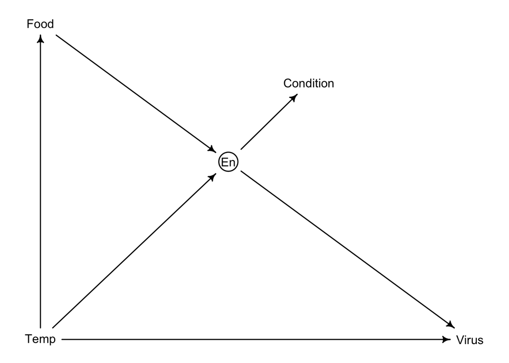

```r
library(dagitty)
library(rethinking)

virus <- dagitty("dag{
Temp -> Food -> En -> Virus
En <- Temp -> Virus
En -> Condition

En [unobserved]
}")
coordinates(virus) <- list(
  x=c(Food=1, En=4.5, Condition=6, Temp=1,  Virus=9),
  y=c(Food=1, En=4.5, Condition=2.5, Temp=9,  Virus=9))
drawdag(virus)
```

```r
dev.off() # remember this trick?
```

Notice that I added back in the measurement of body condition. If you recall from prior labs, we *never* conditioned on this variable to estimate the effect of either temperature or food.

And again, we need some (fake) data to work with. We’ll simulate data from this DAG using the same effect sizes and approach as in prior labs, with all of the variables but `Virus` standardized so that their mean is zero and +/- 1 refers to plus or minus one standard deviation.

```r
set.seed(107)

b_TV <- 0.5 # higher temps increase virus replication
b_TE <- -0.75 # higher temps lead to less energy available
b_FE <- 0.75 # Food has a positive effect on energy available
b_EC <- 0.75 # A pretty good predictor of body condition
b_EV <- -1 # strong, negative effect of energetic reserves

n=30

obs <- data.frame(Temp=rnorm(n=n, mean=0, sd=1))
obs$Food <- rnorm(n=n, mean=obs$Temp*0.5, sd=0.25)
obs$En <- rnorm(n=n,
                mean=b_TE*obs$Temp + b_FE*obs$Food,
                sd=0.25)
obs$Condition <- rnorm(n=n,
                       mean=b_EC*obs$En,
                       sd=0.25)
obs$Virus <- rnorm(n=n,
                   mean=3 + b_EV*obs$En + b_TV*obs$Temp,
                   sd=0.25)
summary(obs)
```

```
      Temp                Food                 En
 Min.   :-1.505307   Min.   :-1.226806   Min.   :-1.114318
 1st Qu.:-0.647441   1st Qu.:-0.357242   1st Qu.:-0.339556
 Median : 0.020780   Median : 0.063752   Median : 0.024435
 Mean   :-0.001058   Mean   :-0.005522   Mean   : 0.009767
 3rd Qu.: 0.574561   3rd Qu.: 0.347946   3rd Qu.: 0.365972
 Max.   : 1.953894   Max.   : 0.920054   Max.   : 0.890488
   Condition             Virus
 Min.   :-0.950863   Min.   :1.480
 1st Qu.:-0.313767   1st Qu.:2.208
 Median : 0.006431   Median :3.202
 Mean   : 0.041979   Mean   :3.010
 3rd Qu.: 0.453546   3rd Qu.:3.672
 Max.   : 1.048190   Max.   :4.769
```

Now, let’s imagine we were interested in three models where viral titers were modeled as a linear function temperature ($T$), temperature and food ($T+F$), and temperature, food, and body condition ($T+F+C$):
$$\begin{align}
m_a: V & \sim T \\
m_b: V & \sim T + F \\
m_c: V & \sim T + F + C
\end{align}$$

First, let’s go ahead and fit all of these.

```r
ma <- quap(
  alist(
    Virus ~ dnorm(mu, sigma),
    mu <- a + bT*Temp,
    # priors
    a ~ dnorm(3, 3),
    bT ~ dnorm(0, 1),
    sigma ~ dexp(1)
  ), data=obs
)

mb <- quap(
  alist(
    Virus ~ dnorm(mu, sigma),
    mu <- a + bT*Temp + bF*Food,
    # priors
    a ~ dnorm(3, 3),
    bT ~ dnorm(0, 1),
    bF ~ dnorm(0, 1),
    sigma ~ dexp(1)
  ), data=obs
)

mc <- quap(
  alist(
    Virus ~ dnorm(mu, sigma),
    mu <- a + bT*Temp + bF*Food + bC*Condition,
    # priors
    a ~ dnorm(3, 3),
    bT ~ dnorm(0, 1),
    bF ~ dnorm(0, 1),
    bC ~ dnorm(0, 1),
    sigma ~ dexp(1)
  ), data=obs
)
```

```r
precis(ma)
```

```
           mean         sd      5.5%     94.5%
a     3.0111667 0.08488040 2.8755114 3.1468220
bT    0.9244027 0.09810135 0.7676178 1.0811876
sigma 0.4650949 0.05936610 0.3702164 0.5599734
```

```r
precis(mb)
```

```
            mean         sd       5.5%      94.5%
a      3.0077414 0.07577890  2.8866320  3.1288507
bT     1.2932747 0.16902902  1.0231337  1.5634157
bF    -0.6925545 0.27217394 -1.1275410 -0.2575679
sigma  0.4151245 0.05331403  0.3299183  0.5003306
```

```r
precis(mc)
```

```
            mean         sd       5.5%      94.5%
a      3.0429565 0.05696949  2.9519082  3.1340047
bT     0.7812267 0.16731431  0.5138261  1.0486273
bF    -0.1660883 0.23600862 -0.5432756  0.2110991
bC    -0.7829010 0.15596019 -1.0321555 -0.5336465
sigma  0.3096326 0.03968861  0.2462025  0.3730627
```

# Measuring & comparing predictive accuracy

Now how do we go about measuring the fit of each of these models? There are, in fact, many, many options! The metric we will be using in this class—and that is used more broadly in model comparison, whatever the statistical philosophy—is the sum of the logs of the probabilities of observing each observation. For our current purposes, we don’t need to think too much about where this comes from, but we just need to think of this as a score for model fit to the data.
$$S(m)=\sum_i^n\log[p(y_i)],$$
where we we simply sum up the log probabilities of each of the $n$ observations.

However, since we have a full distribution of posterior parameter estimates, we need to also consider a bunch of draws from the posterior when calculating the log probability of observing each point, which we call the log-pointwise-predictive density ($lppd$):
$$\text{lppd}(y,\Theta)=\sum_i^n \log \frac{1}{S}\sum_s^Sp(y_i|\Theta),$$
where we take $S$ samples from the posterior, $\Theta$, and average over them for each of the $n$ observations.

The equations are not too terribly if we take them slowly, but thankfully the actual calculations are simple with `rethinking::lppd()`:

```r
lppd(ma)
```

```
 [1] -0.4290948 -0.1751340 -0.9405682 -0.6116230 -0.1688514 -0.1786012
 [7] -0.1853140 -2.1908470 -0.1905802 -0.2399603 -0.2501794 -0.5689078
[13] -4.4455393 -0.1846221 -0.2434645 -0.3492208 -0.2058698 -0.1743400
[19] -0.2278645 -0.6467176 -1.7012283 -0.2394061 -0.2223484 -0.2464061
[25] -0.5374329 -0.4625703 -0.6278780 -0.1583229 -0.1979428 -2.7785612
```

(Don’t get too worried about the negative and positive log-probabilities. Remember, we’re actually finding probability *densities*, which do not need to be bound between zero and one, which means we can get probability densities that are greater than one, the log of which are positive.)

We can sum these to get the total score for model a:

```r
sum(lppd(ma))
```

```
[1] -19.77774
```

However, most of the time you will see people working with *deviance*, which is $-2\times \text{lppd}$

```r
-2*sum(lppd(ma))
```

```
[1] 39.58775
```

OK, with this we can get and compare the *in-sample* deviance for each model:

```r
# total in-sample deviances
( scores_in <- c(-2*sum(lppd(ma)), -2*sum(lppd(mb)), -2*sum(lppd(mc))) )
```

```
[1] 39.63906 32.93352 15.19651
```

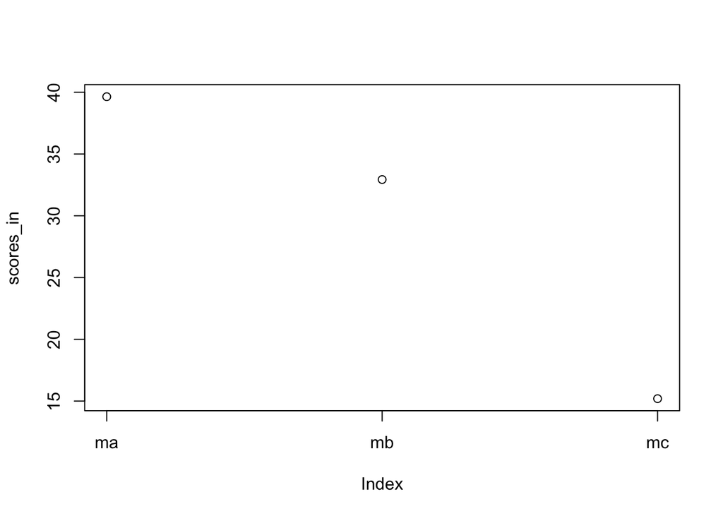

```r
# let's plot these
models <- c("ma", "mb", "mc")
plot(scores_in, xaxt="n")
axis(1, at=1:3, labels =models)
```

Lower values of deviance indicate better fits to the data. (Again, don’t worry about the negatives or positives… this is just a continuous distance score.) So it looks like model a is much worse than the others at predicting the observations, and model c is best. Let’s visualize this just to get a sense of how good/bad these models are at predicting actual (fake) observations. Thankfully, we can recycle some code from before.

```r
# Load in our code to find predicted values and intervals for those predictions
genPreds <- function(df, model, n=1e4, lo=0.055, hi=0.945){
  preds <- rethinking::link(fit=model, data=df, n=n)
  df$preds_mean <- apply(X=preds, MARGIN=2, FUN=mean)
  df$preds_lo <- apply(X=preds, MARGIN=2, FUN=quantile, prob=lo)
  df$preds_hi <- apply(X=preds, MARGIN=2, FUN=quantile, prob=hi)
  return(df)
}
# load code to find posterior predictive distributions
genPPD <- function(df, model, n=1e4, lo=0.055, hi=0.945){
  obs <- rethinking::sim(fit=model, data=df, n=n)
  df$PPD_lo <- apply(X=obs, MARGIN=2, FUN=quantile, prob=lo)
  df$PPD_hi <- apply(X=obs, MARGIN=2, FUN=quantile, prob=hi)
  return(df)
}
```

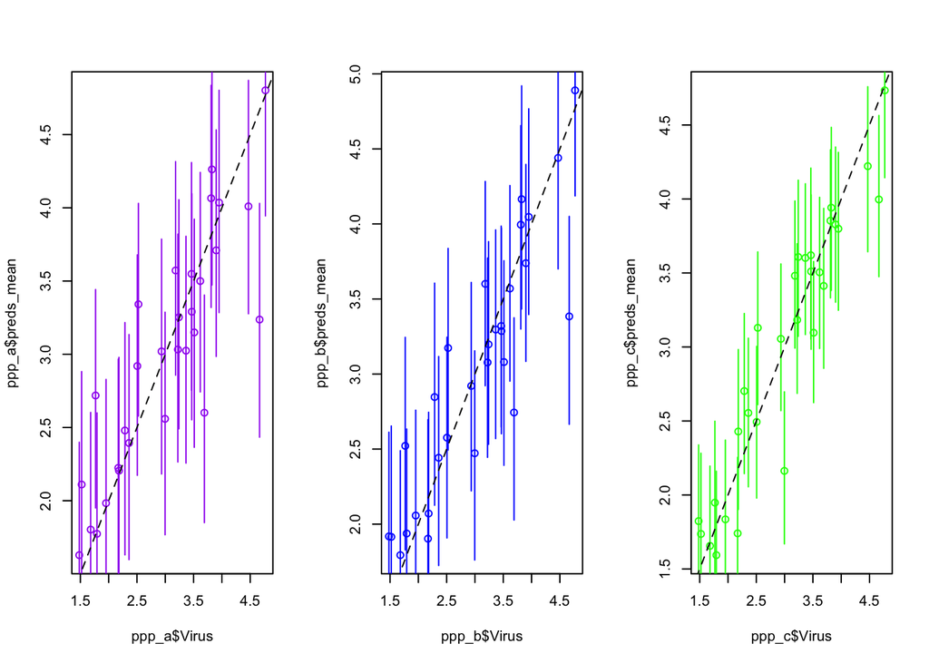

```r
# model a
ppp_a <- genPreds(df=obs,
                model=ma,
                n=1e3)
ppp_a <- genPPD(df=ppp_a,
                model=ma,
                n=1e3)

# model b
ppp_b <- genPreds(df=obs,
                model=mb,
                n=1e3)
ppp_b <- genPPD(df=ppp_b,
                model=mb,
                n=1e3)
# model c
ppp_c <- genPreds(df=obs,
                model=mc,
                n=1e3)
ppp_c <- genPPD(df=ppp_c,
                model=mc,
                n=1e3)

# plot results against actual (fake) observations
par(mfrow=c(1,3)) # <- a way to get three columns
# ma
plot(x=ppp_a$Virus, y=ppp_a$preds_mean, col="purple")
segments(x0=ppp_a$Virus, y0=ppp_a$PPD_lo, y1=ppp_a$PPD_hi, col="purple")
abline(a=0, b=1, lty=2)
#mb
plot(x=ppp_b$Virus, y=ppp_b$preds_mean, col="blue")
segments(x0=ppp_b$Virus, y0=ppp_b$PPD_lo, y1=ppp_b$PPD_hi, col="blue")
abline(a=0, b=1, lty=2)

#mc
plot(x=ppp_c$Virus, y=ppp_c$preds_mean, col="green")
segments(x0=ppp_c$Virus, y0=ppp_c$PPD_lo, y1=ppp_c$PPD_hi, col="green")
abline(a=0, b=1, lty=2)
```

```r
dev.off()
```

So we can see what our deviance scores were telling us: with increasingly complex models we get better and better at accurately predicting our observations.

What we have *not* yet done, however, is compare their ability to predict *new* data.

# Cross validation

Of course, we do not actually *have* new data to try and predict[^1]. Instead, we can leave out some data, fit the model, see how well it predicts the left out data, and repeat. This is called cross validation. We’ll do the so-called “leave one out” or “loo” cross-validation, but this approach is general (e.g., we can divide the data up into $k$ groups and then leave one of these groups out in what is called “$k$-fold” cross-validation). It’s easier to follow if we just do it.

```r
deviances <- matrix(data=NA,
                    nrow=nrow(obs), ncol=3)
colnames(deviances) <- c("ma", "mb", "mc")

for(i in 1:nrow(obs)){
  # subset data
  di <- obs[-i,]
  # fit models to subset of data (with obs i missing)
  ma_temp <- quap(ma@formula, data=di,
                  start=list(a=3,bT=0,sigma=1))
  mb_temp <- quap(mb@formula, data=di,
                  start=list(a=3,bT=0,bF=0,sigma=1))
  mc_temp <- quap(mc@formula, data=di,
                  start=list(a=3,bT=0,bF=0,bC=0,sigma=1))

  # calculate deviance for left out obs i
  deviances[i,1] <- -2*lppd(ma_temp, data=obs[i,])
  deviances[i,2] <- -2*lppd(mb_temp, data=obs[i,])
  deviances[i,3] <- -2*lppd(mc_temp, data=obs[i,])
}
```

If your computer is like mine, this took a while! We’ll want to work on that, soon! But first, what did we get?

```r
# overall scores for out of sample prediction
(scores_out <- colSums(deviances))
```

```
      ma       mb       mc
47.17515 42.63236 27.31329
```

These are the *out-of-sample* deviances for our three models. Let’ see if we can add them to our plot of *in-sample* deviances, from above.

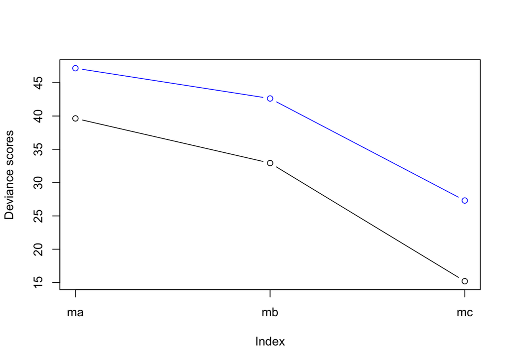

```r
plot(scores_in,
     xaxt="n",
     ylim=c(min(scores_in), max(scores_out)),
     type="b",
     ylab="Deviance scores"
     )
axis(1, at=1:3, labels =models)
points(scores_out, col="blue", type="b")
```

In summary, model c is the best at in-sample prediction *and* out of sample prediction. This is the model that was *never* the right one for causal inference!

# Short-cuts to leave-one-out cross validation

If our goal is leave-one-out cross validation, we have our hands full. We would need to refit and predict the left out observation $n$ times. We just ran it for $n=30$ and probably felt a bit fidgety. Can you imagine what it feels like with $n > 100$? Thankfully, we have some short-cuts. We have two general approaches:

## Pareto-smoothed importance sampling (PSIS)

This is a clever approach where to approximate the lppd for left out observations, we reweight each sample by the inverse of the probability of observing observation $i$ given that sample (plus some pareto-smoothing to avoid things going awry). This is built on the idea that unlikely observations (dare I say outliers?) have more influence on model fit, which means that if they are left out the model fit to the reduced data will change more.

Or, we can just accept that it works for now and run with it!

```r
(psis <- compare(ma, mb, mc, func="PSIS", sort=NULL))
```

```
Some Pareto k values are very high (>1). Set pointwise=TRUE to inspect individual points.
Some Pareto k values are very high (>1). Set pointwise=TRUE to inspect individual points.
Some Pareto k values are very high (>1). Set pointwise=TRUE to inspect individual points.
```

```
       PSIS       SE    dPSIS      dSE    pPSIS       weight
ma 52.89553 17.52873 19.88610 17.41822 6.632438 4.801067e-05
mb 46.84661 16.58824 13.83718 15.64369 6.995474 9.881989e-04
mc 33.00943 14.45574  0.00000       NA 8.966757 9.989638e-01
```

```r
scores_out
```

```
      ma       mb       mc
47.17515 42.63236 27.31329
```

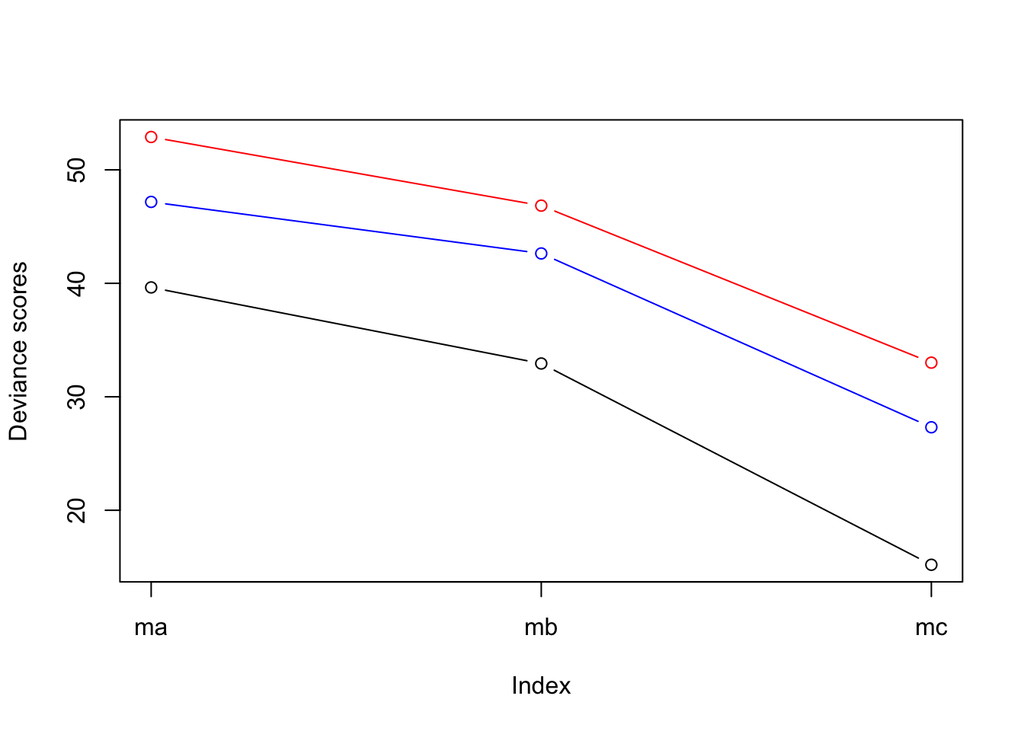

We can see that our PSIS scores (red in this plot) are not exactly the same as our actual cross-validation scores; that’s not surprising. They do, however, capture the general pattern of those scores, which is good. So they are useful approximations. Just don’t take them as if they were incredibly precise. Anyway, they are certainly a lot faster than cross-validation!

## Widely applicable information criterion (WAIC)

The second approach to approximating the out-of-sample deviance is based on adding a penalty for out-of-sample prediction to the in-sample deviance score, which should add up to the out-of-sample deviance scores (approximately).

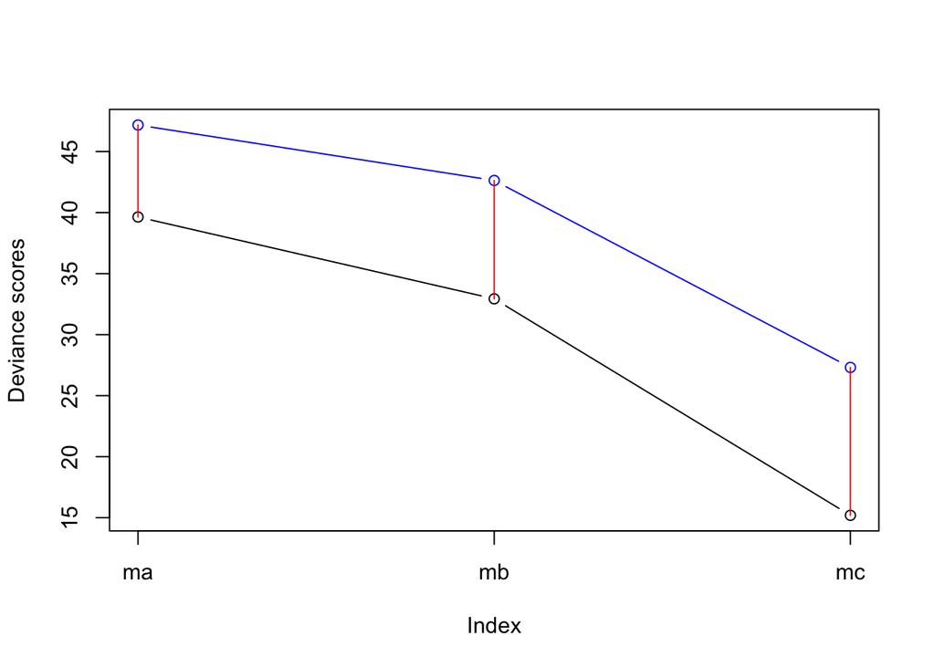

Graphically, we can take the in-sample scores (black points), which are easy to calculate, and add to them a penalty (red segments) to estimate the out-of-sample scores (blue points).

$$\text{WAIC}(y, \Theta)=-2 \left( \text{lppd} - \sum_i^n \text{var}_{\theta} \log p(y_i | \theta) \right)$$

The last part, the variance, is simply the variance in the log-probability of an observation across a bunch of samples from the posterior. Why does this work? Boy howdy! Look at the time! We best just move on and accept it as the “penalty for overfitting”.

Again, the code to implement this has been made for us:

```r
(waic <- compare(ma, mb, mc, func="WAIC", sort=NULL))
```

```
       WAIC       SE    dWAIC      dSE    pWAIC       weight
ma 49.40410 14.56131 20.30787 13.90563 4.899204 3.890214e-05
mb 44.35699 14.43465 15.26077 12.64127 5.727585 4.852191e-04
mc 29.09622 11.76928  0.00000       NA 6.956665 9.994759e-01
```

```r
scores_out
```

```
      ma       mb       mc
47.17515 42.63236 27.31329
```

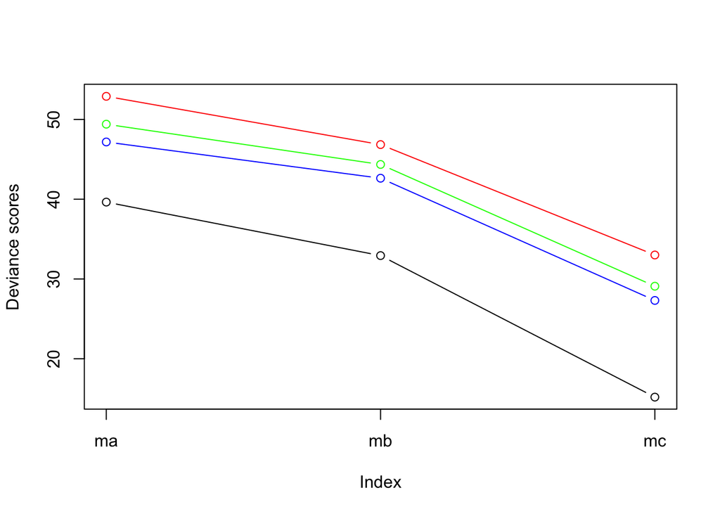

In this case, the WAIC values do a bit better job of approximating the out-of-sample deviance (at least with my simulated data). But again, the idea is that this is a handy approximation, not a perfect one.

# Influential points

You likely saw a message when you called `PSIS()` saying, `Some Pareto k values are very high (>1). Set pointwise=TRUE to inspect individual points.` Let’s take a quick look at these.

```r
PSIS(ma, pointwise=TRUE)
```

```
Some Pareto k values are high (>0.5). Set pointwise=TRUE to inspect individual points.
```

```
         PSIS       lppd    penalty  std_err           k
1   0.8969316 -0.4484658 0.02404915 15.26484  0.14782133
2   0.3686855 -0.1843428 0.01708499 15.26484  0.04179585
3   2.2046054 -1.1023027 0.16087882 15.26484  0.26765447
4   1.3242501 -0.6621251 0.04922720 15.26484  0.23370456
5   0.3581793 -0.1790897 0.01766711 15.26484 -0.06638416
6   0.3800306 -0.1900153 0.01870611 15.26484 -0.12429121
7   0.3966659 -0.1983330 0.01943568 15.26484 -0.05158527
8   5.2661398 -2.6330699 0.41931160 15.26484  0.27737977
9   0.3984821 -0.1992411 0.01855242 15.26484 -0.05739355
10  0.5393866 -0.2696933 0.03581032 15.26484  0.36858506
11  0.5306357 -0.2653179 0.02245216 15.26484  0.03782139
12  1.2033641 -0.6016820 0.03213140 15.26484  0.13019500
13 13.7563740 -6.8781870 2.38376292 15.26484  0.95571349
14  0.3889338 -0.1944669 0.01751329 15.26484  0.03582777
```

[output cut: 16 more lines]

Remember that our PSIS is a summation of reweighted probabilities of observing each observation. It’s thus relatively easy to break this into component parts, one for each observations. The parameter, $k$, tells us something about the importance of each observation to the final model fit. Let’s explore these for each model.

```r
# first, let's just get the pointwise values of k
k_a <- PSIS(ma, pointwise=TRUE, n=1e4)$k
```

```
Some Pareto k values are very high (>1). Set pointwise=TRUE to inspect individual points.
```

```r
k_b <- PSIS(mb, pointwise=TRUE, n=1e4)$k
```

```
Some Pareto k values are very high (>1). Set pointwise=TRUE to inspect individual points.
```

```r
k_c <- PSIS(mc, pointwise=TRUE, n=1e4)$k
```

```
Some Pareto k values are very high (>1). Set pointwise=TRUE to inspect individual points.
```

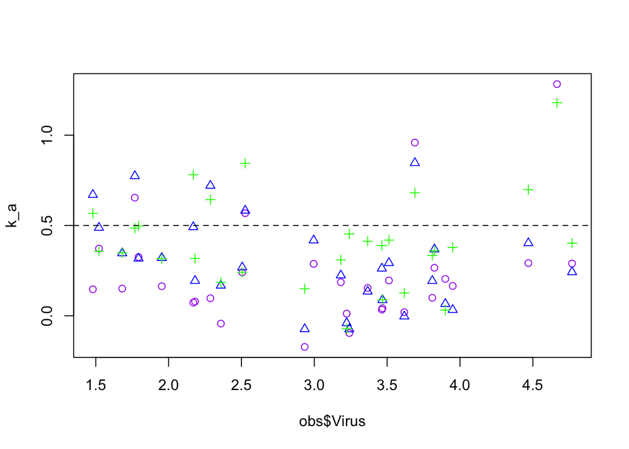

```r
# and plot them according the observed virus titer
plot(obs$Virus, k_a, col="purple", pch=1)
points(obs$Virus, k_b, col="blue", pch=2)
points(obs$Virus, k_c, col="green", pch=3)
abline(h=0.5, lty=2)
```

From this we can see that there are a few observations that are strongly influential to all three models, but otherwise the what is influential in one model is not necessarily very influential in another. This is not uncommon. What might be surprising if we only consider temperature might be pretty much expected if we also consider food availability.

Still, it can be hard to see why some points are influential. Let’s return to our plot of the expected or predicted against the observed values for each model. Only now let’s make the symbol size proportional to the value of k.

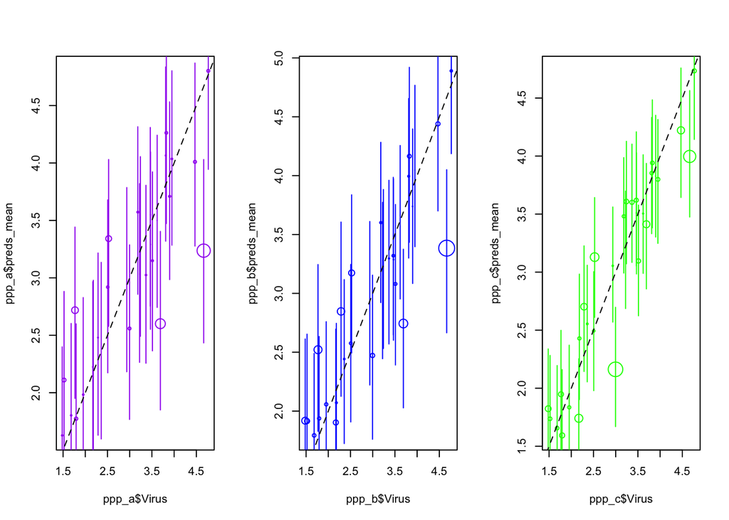

```r
par(mfrow=c(1,3)) # <- a way to get three columns
# ma
plot(x=ppp_a$Virus, y=ppp_a$preds_mean, col="purple",
     cex=2*k_a)
segments(x0=ppp_a$Virus, y0=ppp_a$PPD_lo, y1=ppp_a$PPD_hi, col="purple")
abline(a=0, b=1, lty=2)
#mb
plot(x=ppp_b$Virus, y=ppp_b$preds_mean, col="blue",
     cex=2*k_b)
segments(x0=ppp_b$Virus, y0=ppp_b$PPD_lo, y1=ppp_b$PPD_hi, col="blue")
abline(a=0, b=1, lty=2)

#mc
plot(x=ppp_c$Virus, y=ppp_c$preds_mean, col="green",
     cex=2*k_c)
segments(x0=ppp_c$Virus, y0=ppp_c$PPD_lo, y1=ppp_c$PPD_hi, col="green")
abline(a=0, b=1, lty=2)
```

```r
dev.off()
```

The positions along the x-axis do not change among these panels, so we see where there are influential points across the models and, perhaps, get a sense of why. Digging into the values of predictors can also be helpful. None of this says these models are wrong or bad—indeed, these are “correct” models fit to simulated data, so they are in no way wrong or bad. These just highlight that particular observations have a large effect on the model fit. That can be super useful!

We can do something similar with WAIC, too.

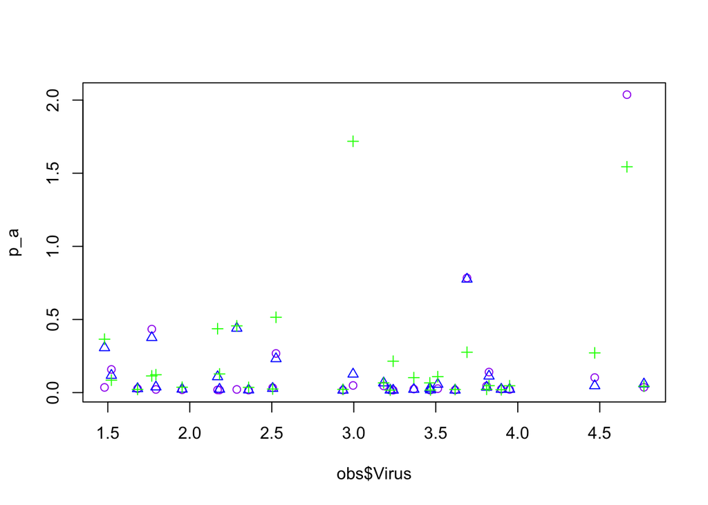

```r
p_a <- WAIC(ma, pointwise=TRUE, n=1e4)$penalty
p_b <- WAIC(mb, pointwise=TRUE, n=1e4)$penalty
p_c <- WAIC(mc, pointwise=TRUE, n=1e4)$penalty

# and plot them according the observed virus titer
plot(obs$Virus, p_a, col="purple", pch=1)
points(obs$Virus, p_b, col="blue", pch=2)
points(obs$Virus, p_c, col="green", pch=3)
```

There are no clear thresholds for the penalties, at least that I’m aware of, but higher does indicate more influential. Moreover, the WAIC penalties and the $k$ values from PSIS are generally correlated.

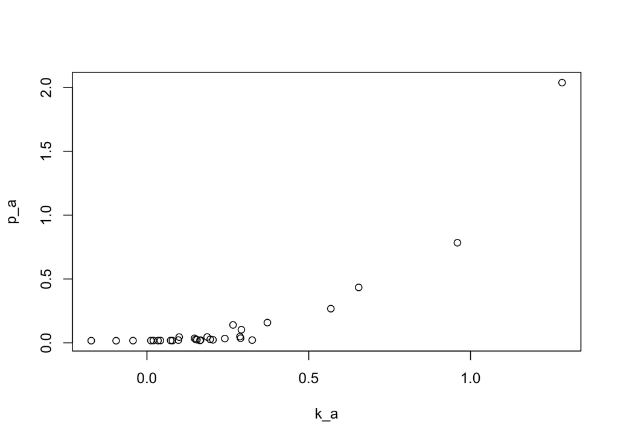

```r
plot(k_a, p_a)
```

```r
# plot(k_b, p_b)
# plot(k_c, p_c)
```

# The impacts of less-surprised distributions on predictive accuracy

What can we do if we’re worried about influential points? That is, what are our options if we suspect that some points are strongly influencing our model fit, but we don’t have a good way to account for or explain why?

One option is to use a distribution to describe our data that has longer tails. Instead of a normal distribution, we could use a student’s t distribution. Instead of a binomial, we could use a beta-binomial. Instead of a Poisson, we could use a negative binomial. (Don’t freak out! I’m not expecting that you know these distributions, let alone why they form these pairs! The point is just that they exist.)

We can motivate using these fat-tailed distributions in a couple ways. First, we might say, “I don’t want my model to be too swayed by values that are further from the mean expectation.” The fat tail gives more probability to those more extreme values than under the skinny-tailed distributions.

```r
dnorm(6, mean=3, sd=1)
```

```
[1] 0.004431848
```

```r
dstudent(6, nu=2, mu=3, sigma=1) # 2 degrees of freedom
```

```
[1] 0.02741012
```

See? That means that the model isn’t pulled as much towards the observation (here, of 6) because it is not extremely unlikely in the student’s t version of things.

The second way to motive the use of a fat-tailed distribution is to acknowledge that there probably isn’t a single sampling distribution across all of the data. That is, while one chunk of data might reasonably be describe as coming from a normal with a standard deviation of $\sigma=0.7$, another chunk might instead have a smaller or larger standard deviation ($\sigma=0.5$ or $\sigma=1.1$). If we lump together a bunch of these different distributions (and make some reasonable assumptions about the distribution of this parameter, here $\sigma$) we get a student’s t distribution. (Or equivalently, a beta-binomial or a negative binomial, AKA beta-Poisson).

Whatever our rationale, we can easily fit models that are less surprised by highly influential observations. In fact, let’s try this!

**Your turn**

I would like you to:

1. re-fit each of our three models using a student’s t distribution with two degrees of freedom, in place of the normal. The code is, `dstudent(2, mu, sigma)`.
2. compare the predictive ability of the models with the more and less surprised distributions using psis or waic.
3. explain the pattern of predictive abilities you observe. That is, why are they more/less/equally good at out of sample prediction?

```r
# re-fit each model
ma_t <- quap(
  alist(
    Virus ~ dstudent(2, mu, sigma),
    mu <- a + bT*Temp,
    # priors
    a ~ dnorm(3, 3),
    bT ~ dnorm(0, 1),
    sigma ~ dexp(1)
  ), data=obs
)

mb_t <- quap(
  alist(
    Virus ~ dstudent(2, mu, sigma),
    mu <- a + bT*Temp + bF*Food,
    # priors
    a ~ dnorm(3, 3),
    bT ~ dnorm(0, 1),
    bF ~ dnorm(0, 1),
    sigma ~ dexp(1)
  ), data=obs
)

mc_t <- quap(
  alist(
    Virus ~ dstudent(2, mu, sigma),
    mu <- a + bT*Temp + bF*Food + bC*Condition,
    # priors
    a ~ dnorm(3, 3),
    bT ~ dnorm(0, 1),
    bF ~ dnorm(0, 1),
    bC ~ dnorm(0, 1),
    sigma ~ dexp(1)
  ), data=obs
)
```

```r
# compare estimated predictive ability
compare(ma, ma_t, mb, mb_t, mc, mc_t, func="PSIS")
```

```
Some Pareto k values are very high (>1). Set pointwise=TRUE to inspect individual points.
```

```
Some Pareto k values are high (>0.5). Set pointwise=TRUE to inspect individual points.
```

```
Some Pareto k values are very high (>1). Set pointwise=TRUE to inspect individual points.
Some Pareto k values are very high (>1). Set pointwise=TRUE to inspect individual points.
```

```
Some Pareto k values are high (>0.5). Set pointwise=TRUE to inspect individual points.
```

```
         PSIS       SE     dPSIS       dSE    pPSIS       weight
mc_t 29.47437 11.56747  0.000000        NA 7.944747 8.263107e-01
mc   32.81085 14.38045  3.336480  7.220865 8.863512 1.558246e-01
mb_t 37.58268 12.42428  8.108318  8.856147 4.435505 1.433655e-02
ma_t 40.49623 13.32380 11.021866 12.067669 3.154454 3.340224e-03
mb   46.35527 15.98243 16.880906 12.294154 6.747224 1.784437e-04
ma   52.21062 17.12323 22.736253 14.682735 6.289965 9.550558e-06
```

```r
# explain the pattern

# Better at fitting: With a less surprised distribution, our models are not pulled as much by more extreme data points. They tend to focus on the "regular features" of the data rather than overfitting. This can make them better at predicting new observations.

# Worse at fitting: With a less surprised distribution, our models may not be learning as much from the data about the "regular features" as they otherwise might. In some cases unexpected values might really be coming from some other process and so we wouldn't want them to pull our model toward them so much, but in this case our observations all come from the same process. There are no "outliers" in our data!
```

# The impacts of skeptical priors on predictive accuracy

Lastly, if we have some sense of what values are reasonable for parameters, we can do a better job of out-of-sample prediction than if we pretend not to know anything.

Again, I’d like you to demonstrate this for yourself. This effect is more obvious with smaller sample sizes—given enough (informative) data, priors hardly matter! So we’ll work with a restricted data set.

**Your turn**

I would like you to:

1. re-fit each of our three models (using a normal distribution) with (a) just the first ten observations in our `obs` data set and then (b), again, with those ten observations *and* a standard deviations of the priors for the slopes set to 10. This is a very broad distribution suggest we know almost nothing about their values. (You can keep the other parameters the same, or change them if you like.)
2. compare the predictive ability of the models with the narrower (first set of models) and wider (new set of models) prior distributions using psis or waic.
3. explain the pattern of predictive abilities you observe. That is, why are they more/less/equally good at out of sample prediction?

```r
# restrict the data set
obs <- obs[1:10,]

# refit the models with n=10
ma <- quap(
  alist(
    Virus ~ dnorm(mu, sigma),
    mu <- a + bT*Temp,
    # priors
    a ~ dnorm(3, 3),
    bT ~ dnorm(0, 1),
    sigma ~ dexp(1)
  ), data=obs
)

mb <- quap(
  alist(
    Virus ~ dnorm(mu, sigma),
    mu <- a + bT*Temp + bF*Food,
    # priors
    a ~ dnorm(3, 3),
    bT ~ dnorm(0, 1),
    bF ~ dnorm(0, 1),
    sigma ~ dexp(1)
  ), data=obs
)

mc <- quap(
  alist(
    Virus ~ dnorm(mu, sigma),
    mu <- a + bT*Temp + bF*Food + bC*Condition,
    # priors
    a ~ dnorm(3, 3),
    bT ~ dnorm(0, 1),
    bF ~ dnorm(0, 1),
    bC ~ dnorm(0, 1),
    sigma ~ dexp(1)
  ), data=obs
)

# refit with wider priors
ma_w <- quap(
  alist(
    Virus ~ dnorm(mu, sigma),
    mu <- a + bT*Temp,
    # priors
    a ~ dnorm(3, 3),
    bT ~ dnorm(0, 10),
    sigma ~ dexp(1)
  ), data=obs
)

mb_w <- quap(
  alist(
    Virus ~ dnorm(mu, sigma),
    mu <- a + bT*Temp + bF*Food,
    # priors
    a ~ dnorm(3, 3),
    bT ~ dnorm(0, 10),
    bF ~ dnorm(0, 10),
    sigma ~ dexp(1)
  ), data=obs
)

mc_w <- quap(
  alist(
    Virus ~ dnorm(mu, sigma),
    mu <- a + bT*Temp + bF*Food + bC*Condition,
    # priors
    a ~ dnorm(3, 3),
    bT ~ dnorm(0, 10),
    bF ~ dnorm(0, 10),
    bC ~ dnorm(0, 10),
    sigma ~ dexp(1)
  ), data=obs
)
```

```r
# compare estimated predictive ability
compare(ma, ma_w, mb, mb_w, mc, mc_w, func="PSIS")
```

```
Some Pareto k values are very high (>1). Set pointwise=TRUE to inspect individual points.
Some Pareto k values are very high (>1). Set pointwise=TRUE to inspect individual points.
Some Pareto k values are very high (>1). Set pointwise=TRUE to inspect individual points.
Some Pareto k values are very high (>1). Set pointwise=TRUE to inspect individual points.
Some Pareto k values are very high (>1). Set pointwise=TRUE to inspect individual points.
Some Pareto k values are very high (>1). Set pointwise=TRUE to inspect individual points.
```

```
         PSIS       SE     dPSIS       dSE     pPSIS       weight
ma   29.14846 14.62740  0.000000        NA  9.703323 6.367469e-01
mb_w 30.43132 13.39223  1.282861  7.593872 11.819972 3.352719e-01
ma_w 35.77884 21.44532  6.630389  8.013888 13.056533 2.313109e-02
mb   38.90360 17.82986  9.755141  9.206235 15.884822 4.849142e-03
mc_w 55.88308 33.88356 26.734621 30.021222 25.156480 9.968222e-07
mc   77.67268 45.16677 48.524220 37.065643 36.132924 1.849551e-11
```

```r
compare(ma, ma_w, mb, mb_w, mc, mc_w, func="WAIC")
```

```
         WAIC       SE      dWAIC        dSE     pWAIC       weight
ma_w 22.11847 10.85297  0.0000000         NA  6.206715 4.202411e-01
ma   22.25402 10.78227  0.1355522  0.7088292  6.219711 3.927026e-01
mb   24.49413 11.61307  2.3756560  4.2599742  8.718600 1.281243e-01
mb_w 26.09240 11.05520  3.9739315  7.7934925  9.695562 5.761960e-02
mc   33.75404 19.42744 11.6355685 18.6428314 14.127116 1.249876e-03
mc_w 39.74091 17.85566 17.6224423 14.4366001 17.128870 6.263741e-05
```

```r
# explain the pattern

# With enough data the priors don't matter much, which is mostly what we're seeing (in my data). However, in general,  models with wide priors are pulled more by the extreme observations because they do not weight them lower, a priori, than the models with narrower priors. This can make them worse at out-of-sample prediction.
```

## Footnotes

[^1]: Yes, since we made up these data from a “True” generating process we could make up more data to predict. However, with real data we won’t have some new data set to predict unless we’ve specifically kept it in reserve. Thus, we’ll use the more general cross-validation approach.